# Kernel Density Estimation

This notebook will demonstrate how to compute and plot histograms and kernel density estimates. For data, we will use daily returns on the S&P 500 index between Jan 1, 1981 and Apr 30, 1991 (identical to the example in Chapter 4 of Ruppert and Matteson). Typically, returns are defined as
$$\begin{align}
r_t & = \frac{P_t - P_{t-1}}{P_{t-1}}.
\end{align}$$
Alternatively, we can use the following approximation to compute returns
$$\begin{align}
r_t & = \log(P_t) - \log(P_{t-1}).
\end{align}$$

We start by getting the data for S&P 500 *prices* (not returns):

```r
library(quantmod)
getSymbols("^GSPC", from="1981-01-01", to="1991-04-30")
```

[output not shown]

```
[1] "GSPC"
```

Next, we use daily adjusted closing prices to compute daily returns using the log approximation:

```r
spRets = diff(log(GSPC$GSPC.Adjusted))
spRets = spRets[-1,]
```

```r
head(spRets)
```

[output not shown]

To make handling of the returns easier later one, we overwrite the returns vector without the first `NA` element:

```r
spRets = spRets[-1,]
```

Let’s now plot the returns.

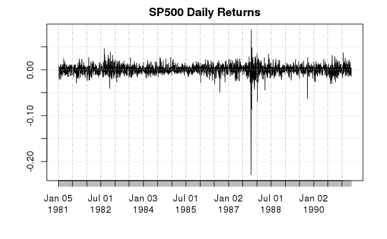

```r
par(bg="white")
plot(spRets, main="SP500 Daily Returns")
```

Histograms of daily returns can be computed with the `hist` function, using the `breaks` argument to determine how many histogram bins we want to fit.

```r
par(mfrow=c(2,2), bg="white")
hist(spRets, breaks=30, xlab="SP500 daily returns", main="30 cells, full range")
hist(spRets, breaks=30, xlim=c(-0.04,0.04), xlab="SP500 daily returns", main="30 cells, central range")
```

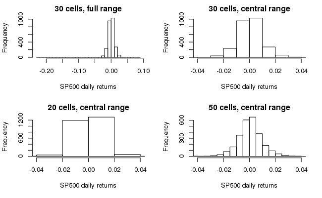

```r
hist(spRets, breaks=20, xlim=c(-0.04,0.04), xlab="SP500 daily returns", main="20 cells, central range")
hist(spRets, breaks=50, xlim=c(-0.04,0.04), xlab="SP500 daily returns", main="50 cells, central range")
```

Notice that we can use the `xlim` argument to adjust the viewable limits of the x-axis. However, this does not change the histogram itself: it still fits a histogram to the full range of data, but just allows you to zoom in on a particular region of the x-axis.

We can now plot kernel density estimates of the daily returns.

```r
par(bg="white")
plot(density(spRets, adjust=1/3), lty=2, main="S&P 500 Daily Returns", xlim=c(-0.04,0.04))
lines(density(spRets))
```

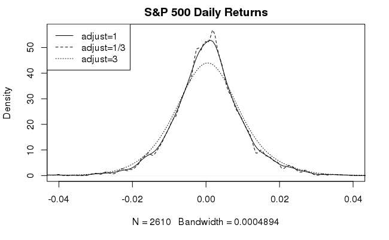

```r
lines(density(spRets, adjust=3), lty=3)
legend("topleft", legend=c("adjust=1", "adjust=1/3", "adjust=3"), lty=c(1,2,3))
```

The `density` function simply computes the KDE of the returns, but doesn’t plot the KDE – by passing the KDE object as an argument to the plot function, you create the visual. If you only use the `density` function to compute (and not plot) the KDE, it would be wise to store it in a variable name for later access.

The `adjust` parameter in the `density` function determines the width (referred to as bandwidth) of the kernel, and hence the smoothness of the KDE. It is expressed in fractions of an optimal kernel bandwidth computed by R, which is normalized to the value 1. KDE smoothness is similar to the number of histogram bins: it is a parameter we control which dictates the final smoothness of the density estimate. Similar to the `hist` function, the `plot` function takes an `xlim` argument.

where $Y$ is a vector of data. Note that MAD is comparable to standard deviation (and not variance) because it is in the same units as $Y$. It is mathematically similar to variance except that averages are replaced by medians and the squared differences are replaced by absolute differences.

```r
par(mfrow=c(1,2), bg="white")
normalDens = rnorm(1000000, mean(spRets), sd(spRets))
plot(density(spRets), xlim=c(-0.04,0.04), main="Standard Estimates")
lines(density(normalDens), lty=2)
```

```r
legend("topleft", legend=c("Estimated density", "Normal density"), lty=c(1,2), cex=0.7, bty='n')
normalDens = rnorm(1000000, median(spRets), mad(spRets))
plot(density(spRets), xlim=c(-0.04,0.04), main="Robust Estimates")
```

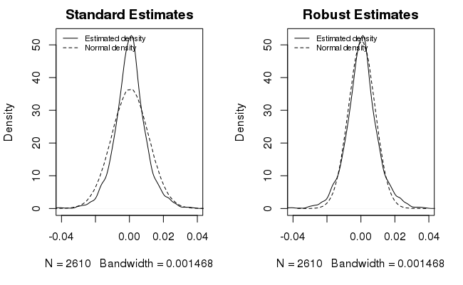

```r
lines(density(normalDens), lty=2)
legend("topleft", legend=c("Estimated density", "Normal density"), lty=c(1,2), cex=0.7, bty='n')
```